# Bellabeat Case Study

Nicole Mister

2024-06-21

This is a case study from the Google Data Analytics Professional Certificate. I will answer key business questions through the data analysis process: ask, prepare, process, analyze, share, and act.

## Ask

### Stakeholders

Urška Sršen: Bellabeat’s cofounder and Chief Creative Officer  
Sando Mur: Mathematician and Bellabeat’s cofounder; key member of the Bellabeat executive team.

Sršen has asked for an analysis of Fitbit smart device usage data in order to gain insight into how consumers use non-Bellabeat smart devices.These questions will guide your analysis:  
1. What are some trends in smart device usage?  
2. How could these trends apply to Bellabeat customers?  
3. How could these trends help influence Bellabeat marketing strategy?

## Prepare

### Data

The data was obtained from https://www.kaggle.com/arashnic/fitbit with the following description:

> This dataset generated by respondents to a distributed survey via Amazon Mechanical Turk between 03.12.2016-05.12.2016. Thirty eligible Fitbit users consented to the submission of personal tracker data, including minute-level output for physical activity, heart rate, and sleep monitoring. Individual reports can be parsed by export session ID (column A) or timestamp (column B). Variation between output represents use of different types of Fitbit trackers and individual tracking behaviors / preferences.

The data is reported to be of 30 self-selected users (33 distinct users during analysis). This small sample size may not reflect the population of Bellabeat users. Self-selected users are not random. The data may be biased. For instance, users willing to participate in the study may be more inclined to be more active than an average user. Additionally, Fitbit users may differ from Bellabeat users.

### Install and load packages

```r
# install.packages("tidyverse")
# install.packages("dplyr")
library(tidyverse)
library(dplyr)
```

### Load the CSV files

```r
daily_activity <- read.csv("dailyActivity_merged.csv")
daily_calories <- read.csv("dailyCalories_merged.csv")
daily_intensities <- read.csv("dailyIntensities_merged.csv")
daily_steps <- read.csv("dailySteps_merged.csv")
heart_rate_seconds <- read.csv("heartrate_seconds_merged.csv")
hourly_calories <- read.csv("hourlyCalories_merged.csv")
hourly_intensities <- read.csv("hourlyIntensities_merged.csv")
hourly_steps <- read.csv("hourlySteps_merged.csv")
minute_calories_narrow <- read.csv("minuteCaloriesNarrow_merged.csv")
minute_intensities_narrow <- read.csv("minuteIntensitiesNarrow_merged.csv")
minute_mets_narrow <- read.csv("minuteMETsNarrow_merged.csv")
minute_sleep <- read.csv("minuteSleep_merged.csv")
minute_steps_narrow <- read.csv("minuteStepsNarrow_merged.csv")
sleep_day <- read.csv("sleepDay_merged.csv")
weight_log <- read.csv("weightLogInfo_merged.csv")
```

### Explore the tables

I explore each table such as the following.

```r
glimpse(daily_activity)
```

```
## Rows: 940
## Columns: 15
## $ Id                       <dbl> 1503960366, 1503960366, 1503960366, 150396036…
## $ ActivityDate             <chr> "4/12/2016", "4/13/2016", "4/14/2016", "4/15/…
## $ TotalSteps               <int> 13162, 10735, 10460, 9762, 12669, 9705, 13019…
## $ TotalDistance            <dbl> 8.50, 6.97, 6.74, 6.28, 8.16, 6.48, 8.59, 9.8…
## $ TrackerDistance          <dbl> 8.50, 6.97, 6.74, 6.28, 8.16, 6.48, 8.59, 9.8…
## $ LoggedActivitiesDistance <dbl> 0, 0, 0, 0, 0, 0, 0, 0, 0, 0, 0, 0, 0, 0, 0, …
## $ VeryActiveDistance       <dbl> 1.88, 1.57, 2.44, 2.14, 2.71, 3.19, 3.25, 3.5…
## $ ModeratelyActiveDistance <dbl> 0.55, 0.69, 0.40, 1.26, 0.41, 0.78, 0.64, 1.3…
## $ LightActiveDistance      <dbl> 6.06, 4.71, 3.91, 2.83, 5.04, 2.51, 4.71, 5.0…
## $ SedentaryActiveDistance  <dbl> 0, 0, 0, 0, 0, 0, 0, 0, 0, 0, 0, 0, 0, 0, 0, …
## $ VeryActiveMinutes        <int> 25, 21, 30, 29, 36, 38, 42, 50, 28, 19, 66, 4…
## $ FairlyActiveMinutes      <int> 13, 19, 11, 34, 10, 20, 16, 31, 12, 8, 27, 21…
## $ LightlyActiveMinutes     <int> 328, 217, 181, 209, 221, 164, 233, 264, 205, …
## $ SedentaryMinutes         <int> 728, 776, 1218, 726, 773, 539, 1149, 775, 818…
## $ Calories                 <int> 1985, 1797, 1776, 1745, 1863, 1728, 1921, 203…
```

```r
n_distinct(daily_activity$Id)
```

```
## [1] 33
```

## Process

I found data cleaning unecessary for the analysis intended in this study.

## Analyze

During exploration, I noticed that there were a different number of users for three of the data tables. This difference is where I focused the analysis.

I created a new data frame containing the name of each table and the distinct number of users.

```r
table_name <- c("daily_activity", "sleep_day", "daily_steps", "heart_rate_seconds", "hourly_calories", "hourly_intensities", "hourly_steps", "minute_calories_narrow", "minute_intensities_narrow", "minute_mets_narrow", "minute_steps_narrow", "weight_log")

number_of_users <- c(n_distinct(daily_activity$Id), n_distinct(sleep_day$Id), n_distinct(daily_steps$Id), n_distinct(heart_rate_seconds$Id), n_distinct(hourly_calories$Id), n_distinct(hourly_intensities$Id), n_distinct(hourly_steps$Id), n_distinct(minute_calories_narrow$Id), n_distinct(minute_intensities_narrow$Id), n_distinct(minute_mets_narrow$Id),  n_distinct(minute_steps_narrow$Id), n_distinct(weight_log$Id))

number_of_users_per_table <- data.frame(table_name, number_of_users)

number_of_users_per_table <- number_of_users_per_table %>% arrange(desc(number_of_users))

number_of_users_per_table$color <- ifelse(number_of_users_per_table$number_of_users < 33, "red", "gray")

number_of_users_per_table$table_name <- factor(number_of_users_per_table$table_name, levels = number_of_users_per_table$table_name)
```

## Share

I created a bar char to visualize the difference in the number of users in the different tables.

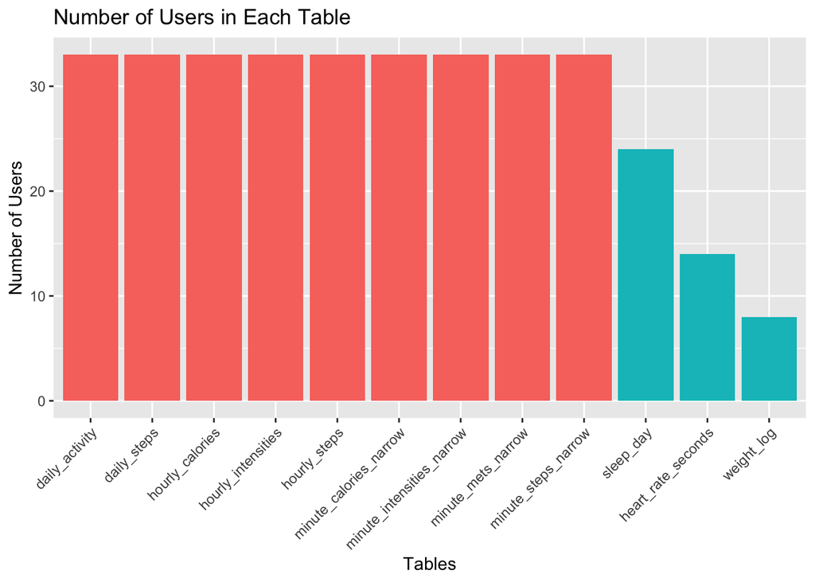

```r
ggplot(number_of_users_per_table, aes(x = table_name, y = number_of_users, fill = color)) +
  geom_bar(stat = "identity") +
  labs(title = "Number of Users in Each Table", x = "Tables", y = "Number of Users") +
  theme(axis.text.x = element_text(angle = 45, hjust = 1)) +
  guides(fill = "none")
```

## Act

The bar chart illustrates that while 33 users participated in nine of the different types of records created, less user participated in three of the tables: sleep, heart rate and weight.

My recommendation would be to determine why users would not or could not submit the sleep, heart rate and weight data. Is this something the users would like to track but are running into difficulties? If the Fitbit device or app lacks in this area, by either device malfunction or user interface difficulties, Bellabeat has an opportunity to improve upon these areas and possibly convert Fitbit users to Bellabeat.